# JELSCH BOND 2_0_0.15_10_Density

## 3d view of density

xyz

yzx

zxy

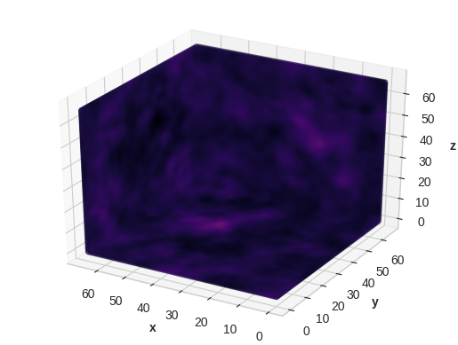

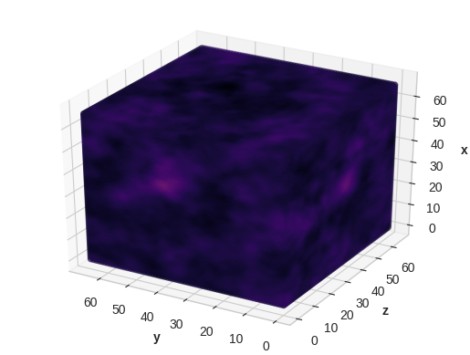

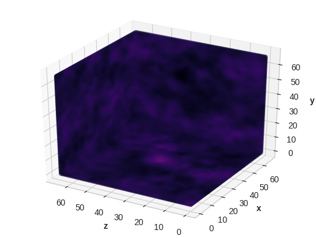

## Slices along x,y and z

Sliced x-wise

Sliced y-wise

Sliced z-wise

0/67

0/67

0/67

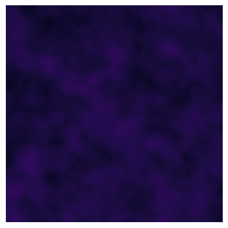

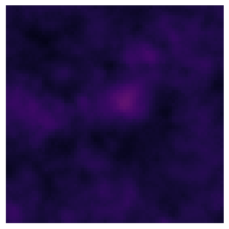

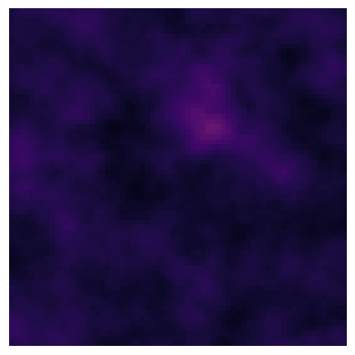

1/67

1/67

1/67

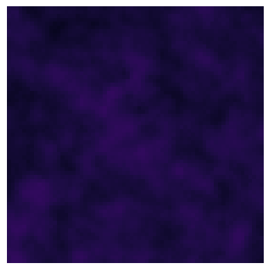

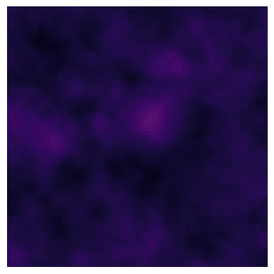

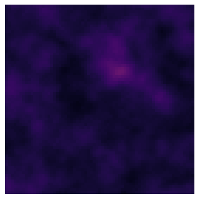

2/67

2/67

2/67

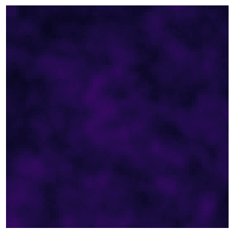

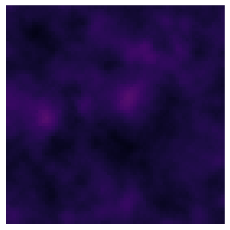

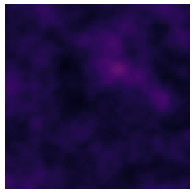

3/67

3/67

3/67

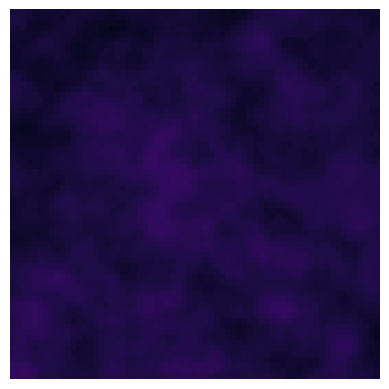

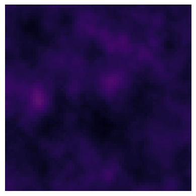

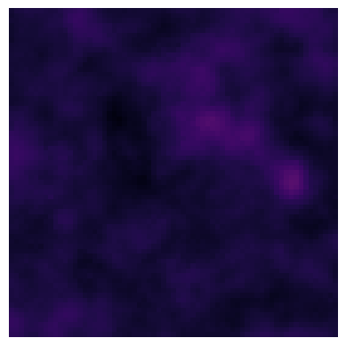

4/67

4/67

4/67

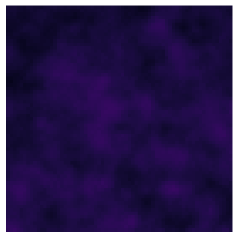

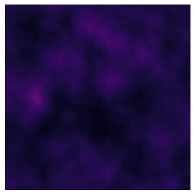

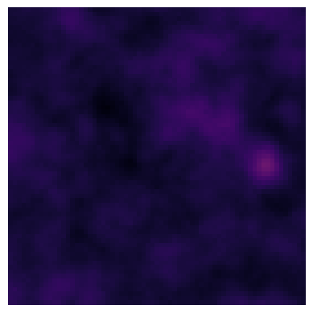

5/67

5/67

5/67

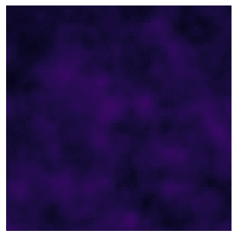

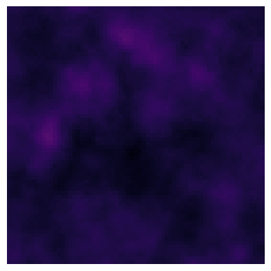

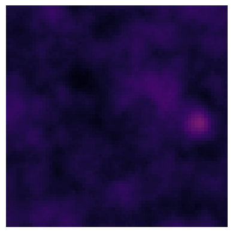

6/67

6/67

6/67

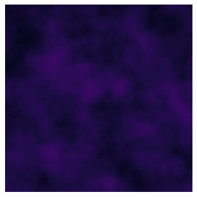

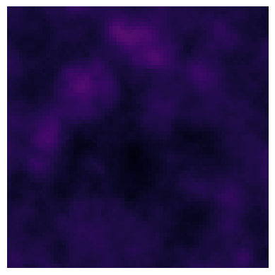

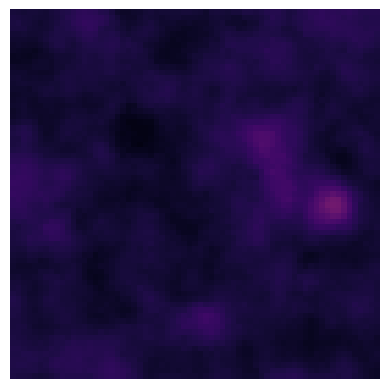

7/67

7/67

7/67

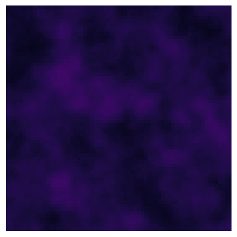

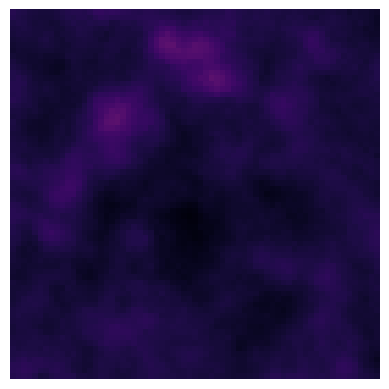

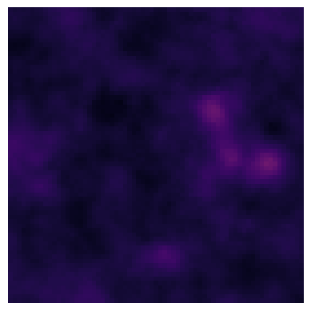

8/67

8/67

8/67

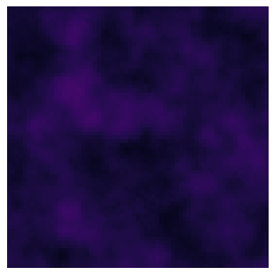

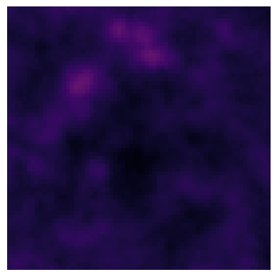

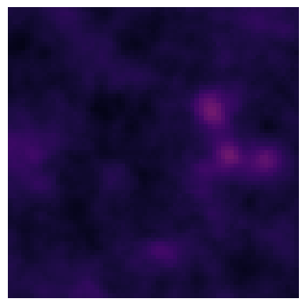

9/67

9/67

9/67

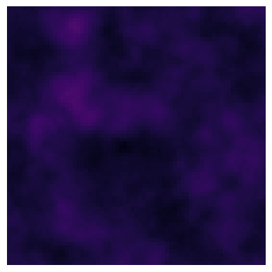

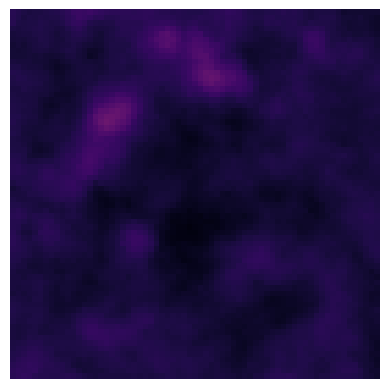

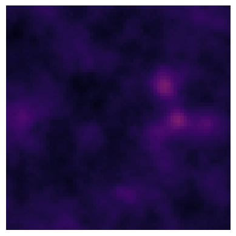

10/67

10/67

10/67

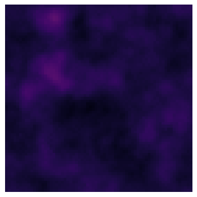

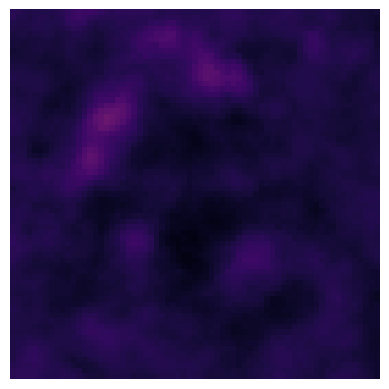

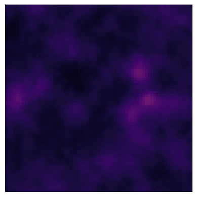

11/67

11/67